# EPIC2: TC all-SNPs vignette

### Component effect statistics by cell group

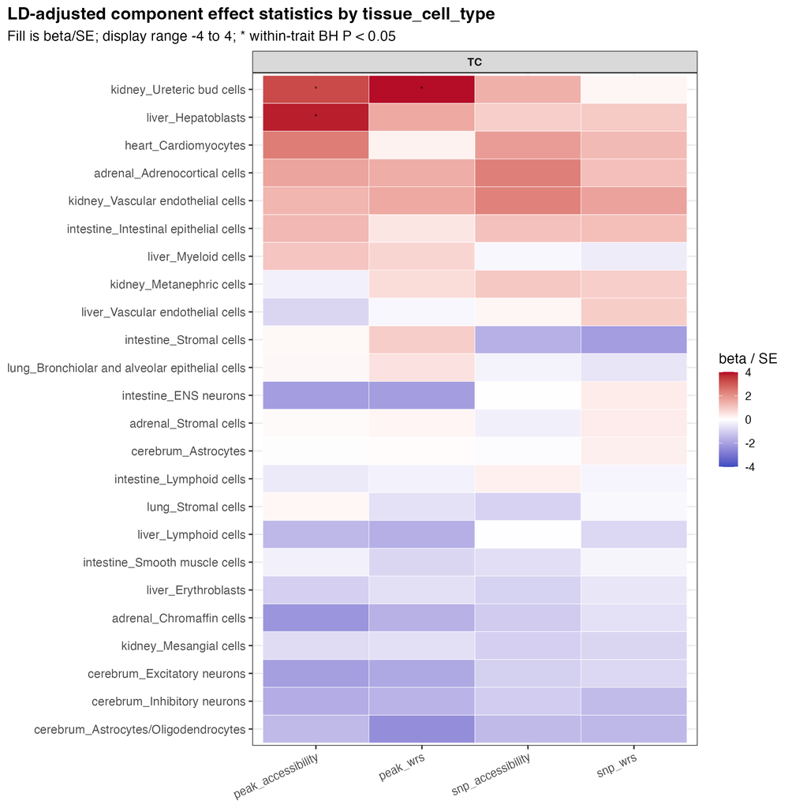

Colors show beta/SE on the symmetric display scale indicated in the legend; stars indicate within-trait BH-adjusted P < 0.05. PDF

### ACAT associations by tissue

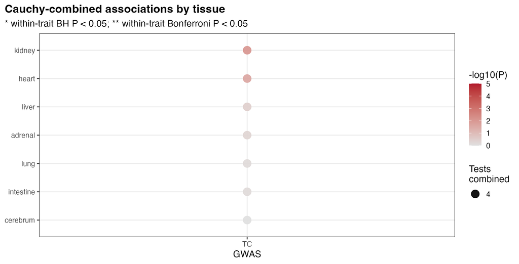

Color shows nominal −log10(P); point size shows the number of combined tests. * BH-adjusted P < 0.05; ** Bonferroni-adjusted P < 0.05. PDF

### Nominal component and ACAT tests by tissue

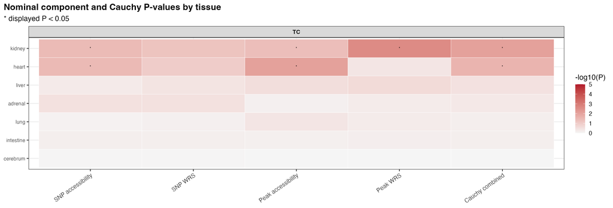

Nominal P-values for the four components and ACAT; stars indicate displayed P < 0.05. PDF

### BH-adjusted component and ACAT tests by tissue

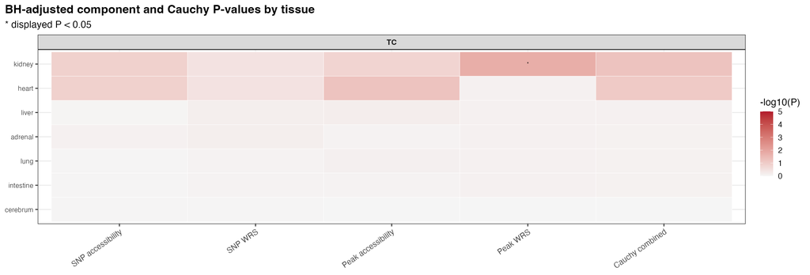

BH-adjusted P-values for the four components and ACAT; stars indicate displayed P < 0.05. PDF

### Bonferroni-adjusted component and ACAT tests by tissue

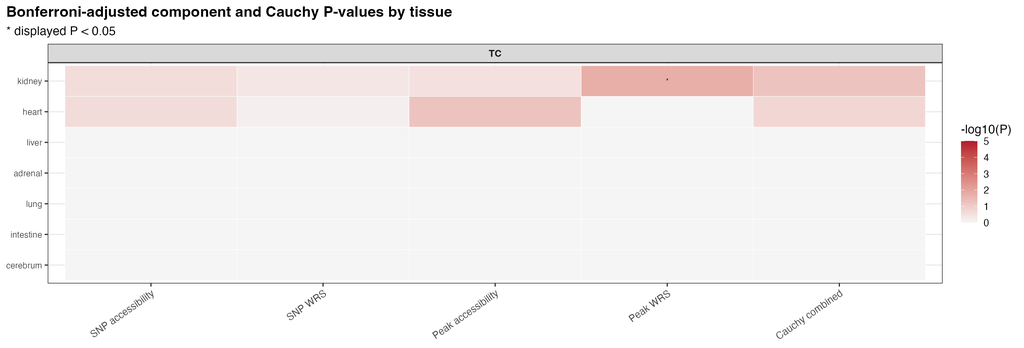

Bonferroni-adjusted P-values for the four components and ACAT; stars indicate displayed P < 0.05. PDF

### Component effect statistics by tissue

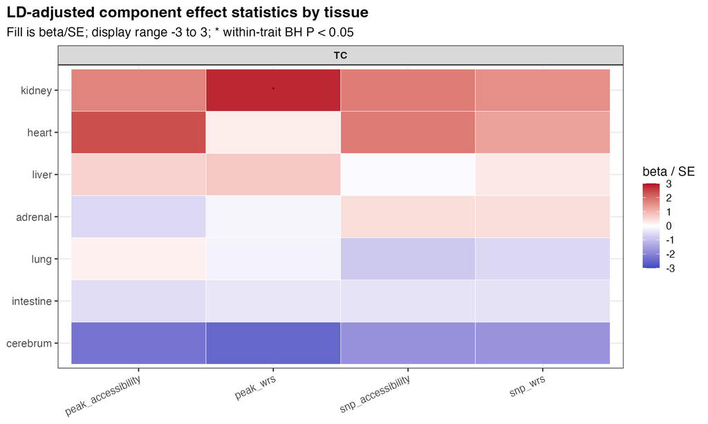

Colors show beta/SE on the symmetric display scale indicated in the legend; stars indicate within-trait BH-adjusted P < 0.05. PDF